# IE 440 - HW 2

Yusuf Ulucoban - Mustafa Comert

207402021 - 2017402141

### Creation of Cij Matrix

According to question, Cij = hj * cij which gives us the total cost of assigning facility i to customer j per unit distance is calculated right after reading the data.

```r
h = as.matrix(read.csv("C:/Users/yuluc/OneDrive/Desktop/demands_13.csv", header=FALSE))
a = as.matrix(read.csv("C:/Users/yuluc/OneDrive/Desktop/coordinates_13.csv", header=FALSE))
c = as.matrix(read.csv("C:/Users/yuluc/OneDrive/Desktop/costs_13.csv", header=FALSE))
```

```r
totalcost = data.table()
for(i in 1:50)
  totalcost <- c(totalcost, c[i,] * t(h))
totalcost <- matrix(unlist(totalcost),50,100)
```

### Euclidian Distance Functions is Ready

Since the functions of euclidian and squared euclidian distance formulas will be used, it is wise that creation of theİr functions.

```r
squared_euclidean <- function(a, b) sum((a - b)^2)
euclidean <- function(a, b) sqrt(sum((a - b)^2))
```

For further calculations, the facility 20 is selected randomly and will be used for next steps.

### Question 1 according to Facility #20

```r
nominator1 = 0
nominator2 = 0
denominator = 0
for(i in 1:100){
  nominator1 = nominator1 + totalcost[20,i] * a[[i,1]]
}
for(i in 1:100){
  nominator2 = nominator2 + totalcost[20,i] * a[[i,2]]
}
for(i in 1:100){
  denominator = denominator + totalcost[20,i]
}

x1 = nominator1/denominator
x2 = nominator2/denominator
facility = t(matrix(c(x1,x2)))
ffacility <- facility

as.numeric(facility)
```

```
## [1] 50.49158 54.81952
```

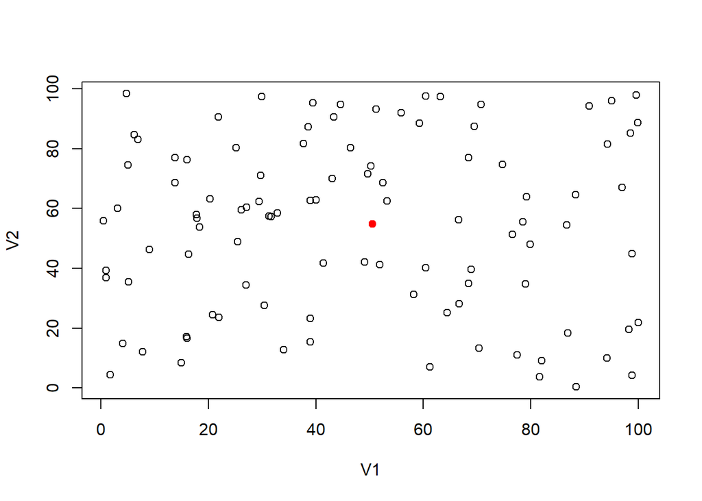

```r
plot(a)
points(facility, col="red", pch=19)
```

Also, the objective value should be calculated and you can observe it in the next lines.

```r
distance_matrix = NULL
for(i in 1:100){
  distance_matrix = cbind(distance_matrix, squared_euclidean(facility, (a[i,])))
}

objectivevalue = as.numeric(totalcost[20,] %*% t(distance_matrix[]))
objectivevalue
```

```
## [1] 183919978
```

### Question 2 and Weiszfeld Algorithm

In the second question, the Weiszfeld algorithm will be used to detect optimal point that facility will be opened. However, that algorithm needs a starting point x0 which will be the point that is derived in the Question1.

```r
iterations = cbind(0,facility,objectivevalue)
j=1
while(j<25){
nominator1 = 0
nominator2 = 0
denominator = 0
for(i in 1:100){
  nominator1 = nominator1 + (totalcost[20,i] * a[[i,1]]) / (euclidean(facility,a[i,]))
}
for(i in 1:100){
  nominator2 = nominator2 + (totalcost[20,i] * a[[i,2]]) / (euclidean(facility,a[i,]))
}
for(i in 1:100){
  denominator = denominator + totalcost[20,i] / (euclidean(facility,a[i,]))
}
x1new = nominator1/denominator
x2new = nominator2/denominator
facility = t(matrix(c(x1new,x2new)))
distance_matrix = NULL
for(i in 1:100){
  distance_matrix = cbind(distance_matrix, euclidean(facility, (a[i,])))
}
objnew = totalcost[20,] %*% t(distance_matrix[])
newrow = t(matrix(c(j,x1new,x2new,objnew)))
iterations = rbind(iterations,newrow)
j = j+1
}
```

Also, it is possible to see each iteration in the below, where first column represents iterations, second and third column represent coordinates and the last column shows the objective value.  
Since the previous question used squared euclidian distance while others use euclidian, the objective value of 0th iteration is way higher than next ones.

```r
iterations
```

```
##                            objectivevalue
##  [1,]  0 50.49158 54.81952      183919978
##  [2,]  1 49.35456 56.12767        4023687
##  [3,]  2 48.76525 56.78192        4021802
##  [4,]  3 48.45708 57.10173        4021319
##  [5,]  4 48.29456 57.25606        4021196
##  [6,]  5 48.20840 57.33006        4021164
##  [7,]  6 48.16259 57.36547        4021156
##  [8,]  7 48.13821 57.38240        4021154
##  [9,]  8 48.12523 57.39050        4021153
## [10,]  9 48.11832 57.39439        4021153
## [11,] 10 48.11465 57.39625        4021153
## [12,] 11 48.11269 57.39715        4021153
## [13,] 12 48.11165 57.39758        4021153
## [14,] 13 48.11110 57.39779        4021153
## [15,] 14 48.11080 57.39789        4021153
## [16,] 15 48.11065 57.39794        4021153
## [17,] 16 48.11056 57.39796        4021153
## [18,] 17 48.11052 57.39797        4021153
## [19,] 18 48.11050 57.39798        4021153
## [20,] 19 48.11048 57.39798        4021153
## [21,] 20 48.11048 57.39798        4021153
## [22,] 21 48.11047 57.39798        4021153
## [23,] 22 48.11047 57.39798        4021153
## [24,] 23 48.11047 57.39798        4021153
## [25,] 24 48.11047 57.39798        4021153
```

It turns out that, facility location is moved to 48.11047, 57.39798.  
Now, it is wise to plot facility locations not only from q1 but also from q2 with the customers.

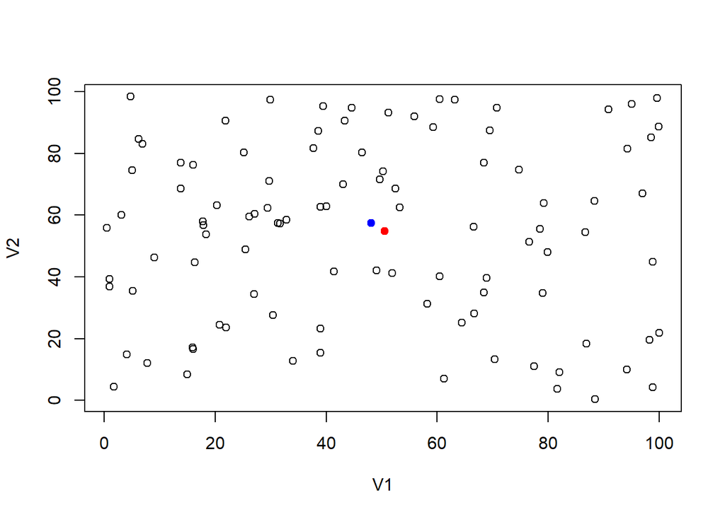

```r
plot(a)
points(ffacility, col="red", pch=19)
points(48.11047,57.39798, col="blue", pch=19)
```

Now, it is observable that the blue point which is new is located upper and more to the left.

### Question 3, Random Assignment and Further Calculations

As the question asks, firstly the customers should be assigned to the facilities randomly. In order to do that, the code that is shown below is used. 50x100 allocation_matrix is created that represents yij binary variable which takes the value 1 if customer j is assigned to facility i and 0 otherwise. Also, random_matrix is created which shows sets of customers for each facility in ther rows.

```r
random_matrix  = matrix(rep(0,200), nrow=50,ncol=2)
allocation_matrix = matrix(rep(0,5000), nrow=50,ncol=100)
order = matrix(sample(c(1:100)),nrow = 50, ncol = 2)
for(i in 1:50){
  for(j in 1:2){
    random_matrix[i,j] = order[i,j]
    allocation_matrix[i,random_matrix[i,j]] = 1
  }
}
```

Now, we have one facility for each two randomly selected customers. To record these customers, their server facility and its locations we update our random_matrix as follows. Also, we use formulas to detect their location for each facility.

```r
random_matrix <- cbind(random_matrix, matrix(rep(0,150),nrow=50,ncol=3))
for(j in 1:50){
  tempa = a[random_matrix[j,],]
  nominator1 = 0
  nominator2 = 0
  denominator = 0
  for(i in 1:2){
    nominator1 = nominator1 + totalcost[j,i] * tempa[[i,1]]
  }
  for(i in 1:2){
    nominator2 = nominator2 + totalcost[j,i] * tempa[[i,2]]
  }
  for(i in 1:2){
    denominator = denominator + totalcost[j,i]
  }

  x1 = nominator1/denominator
  x2 = nominator2/denominator
  facility <- t(matrix(c(x1,x2)))
  distance_matrix = NULL
    for(i in 1:2){
      distance_matrix = cbind(distance_matrix, squared_euclidean(facility, (a[random_matrix[j,i],])))
    }
    objectivevalue = c(totalcost[j,random_matrix[j,1]],totalcost[j, random_matrix[j,2]]) %*% t(distance_matrix[])

  random_matrix[j,3] = x1
  random_matrix[j,4] = x2
  random_matrix[j,5] = objectivevalue
}
iterates = t(matrix(c(0,sum(random_matrix[,5]),50)))
random1_matrix = random_matrix
```

```r
head(random_matrix)
```

```
##      [,1] [,2]     [,3]     [,4]      [,5]
## [1,]   80    9 74.25009 35.47442 1869703.6
## [2,]   96   73 17.26988 77.63176  660366.2
## [3,]   14   98 37.23491 68.62285  512544.7
## [4,]   45   90 45.42812 51.85847 1585092.0
## [5,]   72   95 71.07618 51.43794 4086182.4
## [6,]   94   68 97.85102 33.63596  679590.8
```

You can derive total objective value by summing them up.

```r
sum(random_matrix[,5])
```

```
## [1] 126612849
```

Also, it is possible to visualize their locations where reds are facility and whites are customers. However, there will be many.

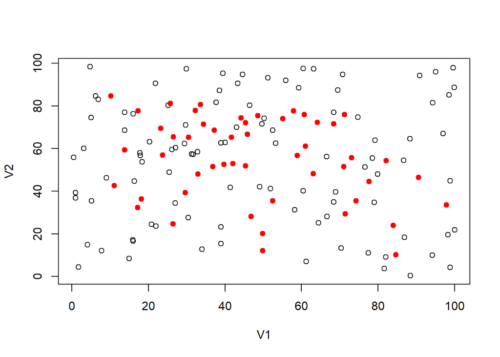

```r
plot(a)
points(random_matrix[,3:4], col="red", pch=19)
```

Now, the next step is calculate all of the distances and decide which facility is the nearest one for the customer i.

```r
nearestmatrix = matrix(rep(0,200),nrow=100,ncol=2)
for(j in 1:100){
  mindist = 9999999999999999999999
  for(i in 1:50){
    if(squared_euclidean(a[j,],random_matrix[i,3:4]) < mindist){
      mindist = squared_euclidean(a[j,],random_matrix[i,3:4])
      nearestf = i
    }
  }
  nearestmatrix[j,] = c(j,nearestf)
}
```

100x2 nearestmatrix shows each customer and the facility that is the nearest to it where first column shows customer and second shows the nearest facility.

```r
head(nearestmatrix)
```

```
##      [,1] [,2]
## [1,]    1   19
## [2,]    2    9
## [3,]    3   46
## [4,]    4   35
## [5,]    5   24
## [6,]    6   47
```

The next step should be assisgning the nearest facility to customers. The code is below.

```r
totalobjectivefirst = 0
facilitiesupdated = NULL
for(i in 1:50){
  tempset = NULL
  for(j in 1:100){
    if(nearestmatrix[j,2] == i){
      tempset = cbind(tempset,j)
    }
  }

  if(is.null(tempset) == TRUE) next

  locationmatrix <- cbind(i,tempset)
  nominator1 = 0
  nominator2 = 0
  denominator = 0

  for(k in 2:length(locationmatrix)){
    nominator1 = nominator1 + totalcost[i,locationmatrix[k]] * a[[locationmatrix[k],1]]
  }

  for(k in 2:length(locationmatrix)){
    nominator2 = nominator2 + totalcost[i,locationmatrix[k]] *  a[[locationmatrix[k],2]]
  }

  for(k in 2:length(locationmatrix)){
    denominator = denominator + totalcost[i,locationmatrix[k]]
  }

  x1 = nominator1/denominator
  x2 = nominator2/denominator
  facilitiesupdated = rbind(facilitiesupdated, c(i, x1, x2))
  facility <- t(matrix(c(x1,x2)))
  distance_matrix = NULL
  for (k in 1 : length(tempset)) {
    distance_matrix = cbind(distance_matrix, squared_euclidean(facility, (a[tempset[1,k],])))
  }

  currenttotal = NULL
  for(k in 1 : length(tempset)){
    currenttotal = cbind(currenttotal, totalcost[i,tempset[1,k]])
  }
  totalobjectivefirst = totalobjectivefirst + currenttotal[] %*% t(distance_matrix[])
}
totalobjective = totalobjectivefirst
n=1
iterates <- rbind(iterates, t(matrix(c(n,totalobjectivefirst,nrow(facilitiesupdated)))))
```

In this step, we allocate all the facilities and locate them according to their distances from customers. Also, the number of the facility is changed because there is some facility that is not the closest one to any customer. So, in order to track and record these numbers, we use a matrix named iterates.  
Also, the main goal of the work is compare their objective values. So, they are recorded too.  
You can observe iterate matrix which is ready for only first step yet below.

```r
iterates
```

```
##      [,1]      [,2] [,3]
## [1,]    0 126612849   50
## [2,]    1   7956015   36
```

Now, to not get involved each step of the algorithm, we automize it and focus only iterates matrix to observe.  
Also, code is below to investigate.

```r
temp = 0
while(abs(totalobjective - temp) > 0.001){
  temp = totalobjective
  nearestmatrix = matrix(rep(0,200),nrow=100,ncol=2)
  for(j in 1:100){
    mindist = 9999999999999999999999
    nearestf = 0
    for(i in 1:length(facilitiesupdated[,1])){
      if(squared_euclidean(a[j,],facilitiesupdated[i,2:3]) < mindist){
        mindist = squared_euclidean(a[j,],facilitiesupdated[i,2:3])
        nearestf = facilitiesupdated[i,1]
      }
    }
    nearestmatrix[j,] = c(j,nearestf)
  }
  facilitiesupdated = NULL
  locationmatrix = NULL
  totalobjective = 0

  for(i in 1:50){

    tempset = NULL
    for(j in 1:100){
      if(nearestmatrix[j,2] == i){
        tempset = cbind(tempset,j)
      }
    }

    if(is.null(tempset) == TRUE) next

    locationmatrix <- cbind(i,tempset)
    nominator1 = 0
    nominator2 = 0
    denominator = 0

    for(k in 2:length(locationmatrix)){
      nominator1 = nominator1 + totalcost[i,locationmatrix[k]] * a[[locationmatrix[k],1]]
    }

    for(k in 2:length(locationmatrix)){
      nominator2 = nominator2 + totalcost[i,locationmatrix[k]] *  a[[locationmatrix[k],2]]
    }

    for(k in 2:length(locationmatrix)){
      denominator = denominator + totalcost[i,locationmatrix[k]]
    }

    x1 = nominator1/denominator
    x2 = nominator2/denominator
    facilitiesupdated = rbind(facilitiesupdated, c(i, x1, x2))
    facility <- t(matrix(c(x1,x2)))
    distance_matrix = NULL
    for (k in 1 : length(tempset)) {
      distance_matrix = cbind(distance_matrix, squared_euclidean(facility, (a[tempset[1,k],])))
    }

    currenttotal = NULL
    for(k in 1 : length(tempset)){
      currenttotal = cbind(currenttotal, totalcost[i,tempset[1,k]])
    }
    totalobjective = totalobjective + currenttotal[] %*% t(distance_matrix[])


  }
  n=n+1
  iterates <- rbind(iterates, t(matrix(c(n,totalobjective,nrow(facilitiesupdated)))))
}
```

We can observe iterates again to analyze our algorithm.

```r
iterates
```

```
##      [,1]      [,2] [,3]
## [1,]    0 126612849   50
## [2,]    1   7956015   36
## [3,]    2   5465176   36
## [4,]    3   4644459   36
## [5,]    4   4218443   36
## [6,]    5   3932678   36
## [7,]    6   3803874   36
## [8,]    7   3803874   36
```

Since our facility number does not decrease always, we need to check their places.

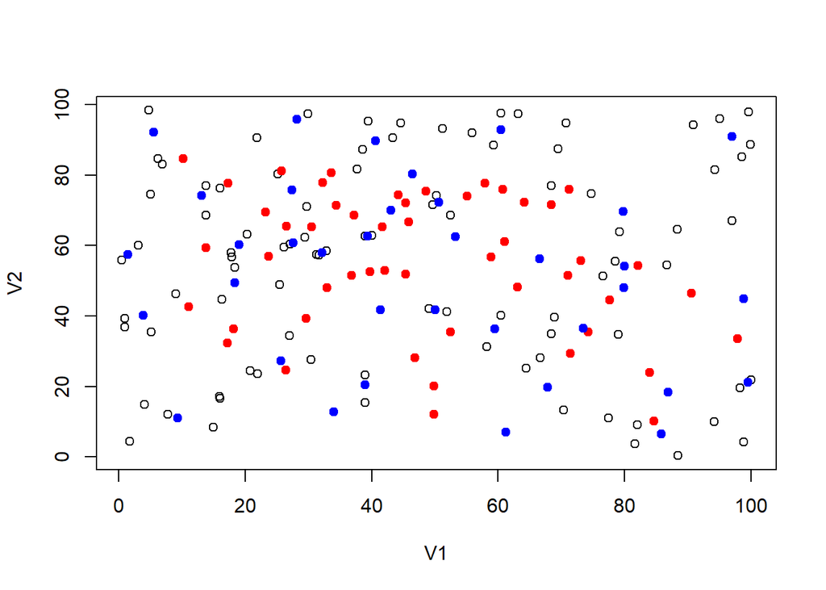

```r
plot(a)
points(random_matrix[,3:4], col="red", pch=19)
points(facilitiesupdated[,2:3], col="blue", pch=19)
```

It is proved that algorithm works fine because locations of facilities are changed. So, we can say that our objective value and number of facilities are as shown as below.

```r
as.numeric(tail(iterates[,2:3],1))
```

```
## [1] 3803874      36
```

### Question 3, Average and Best Results for 1000 Trials

Since we want to run query for 1000 times, the code is updated with while loop and added below. Also, trials matrix is created that shows optimal values in first column and number of facilities in second column.

```r
trials = matrix(rep(0,2000), nrow=1000,ncol=2)
number.of.trials = 1
while (number.of.trials < 1001){
  random_matrix  = matrix(rep(0,200), nrow=50,ncol=2)
  allocation_matrix = matrix(rep(0,5000), nrow=50,ncol=100)
  order = matrix(sample(c(1:100)),nrow = 50, ncol = 2)
  for(i in 1:50){
    for(j in 1:2){
      random_matrix[i,j] = order[i,j]
      allocation_matrix[i,random_matrix[i,j]] = 1
    }
  }

  random_matrix <- cbind(random_matrix, matrix(rep(0,150),nrow=50,ncol=3))

  for(j in 1:50){
    tempa = a[random_matrix[j,],]
    nominator1 = 0
    nominator2 = 0
    denominator = 0
    for(i in 1:2){
      nominator1 = nominator1 + totalcost[j,i] * tempa[[i,1]]
    }
    for(i in 1:2){
      nominator2 = nominator2 + totalcost[j,i] * tempa[[i,2]]
    }
    for(i in 1:2){
      denominator = denominator + totalcost[j,i]
    }

    x1 = nominator1/denominator
    x2 = nominator2/denominator
    facility <- t(matrix(c(x1,x2)))
    distance_matrix = NULL
    for(i in (2*j - 1): (2*j)){
      distance_matrix = cbind(distance_matrix, squared_euclidean(facility, (a[i,])))
    }

    objectivevalue = totalcost[j,(j*2-1):(j*2)] %*% t(distance_matrix[])

    random_matrix[j,3] = x1
    random_matrix[j,4] = x2
    random_matrix[j,5] = objectivevalue

  }

  sum(random_matrix[,5])



  iterates = t(matrix(c(0,sum(random_matrix[,5]),50)))


  nearestmatrix = matrix(rep(0,200),nrow=100,ncol=2)
  for(j in 1:100){
    mindist = 9999999999999999999999
    for(i in 1:50){
      if(squared_euclidean(a[j,],random_matrix[i,3:4]) < mindist){
        mindist = squared_euclidean(a[j,],random_matrix[i,3:4])
        nearestf = i
      }
    }
    nearestmatrix[j,] = c(j,nearestf)
  }
  totalobjectivefirst = 0
  facilitiesupdated = NULL
  for(i in 1:50){
    tempset = NULL
    for(j in 1:100){
      if(nearestmatrix[j,2] == i){
        tempset = cbind(tempset,j)
      }
    }

    if(is.null(tempset) == TRUE) next

    locationmatrix <- cbind(i,tempset)
    nominator1 = 0
    nominator2 = 0
    denominator = 0

    for(k in 2:length(locationmatrix)){
      nominator1 = nominator1 + totalcost[i,locationmatrix[k]] * a[[locationmatrix[k],1]]
    }

    for(k in 2:length(locationmatrix)){
      nominator2 = nominator2 + totalcost[i,locationmatrix[k]] *  a[[locationmatrix[k],2]]
    }

    for(k in 2:length(locationmatrix)){
      denominator = denominator + totalcost[i,locationmatrix[k]]
    }

    x1 = nominator1/denominator
    x2 = nominator2/denominator
    facilitiesupdated = rbind(facilitiesupdated, c(i, x1, x2))
    facility <- t(matrix(c(x1,x2)))
    distance_matrix = NULL
    for (k in 1 : length(tempset)) {
      distance_matrix = cbind(distance_matrix, squared_euclidean(facility, (a[tempset[1,k],])))
    }

    currenttotal = NULL
    for(k in 1 : length(tempset)){
      currenttotal = cbind(currenttotal, totalcost[i,tempset[1,k]])
    }
    totalobjectivefirst = totalobjectivefirst + currenttotal[] %*% t(distance_matrix[])
  }
  totalobjective = totalobjectivefirst
  n=1
  iterates <- rbind(iterates, t(matrix(c(n,totalobjectivefirst,nrow(facilitiesupdated)))))


  temp = 0
  while(abs(totalobjective - temp) > 0.001){
    temp = totalobjective
    nearestmatrix = matrix(rep(0,200),nrow=100,ncol=2)
    for(j in 1:100){
      mindist = 9999999999999999999999
      nearestf = 0
      for(i in 1:length(facilitiesupdated[,1])){
        if(squared_euclidean(a[j,],facilitiesupdated[i,2:3]) < mindist){
          mindist = squared_euclidean(a[j,],facilitiesupdated[i,2:3])
          nearestf = facilitiesupdated[i,1]
        }
      }
      nearestmatrix[j,] = c(j,nearestf)
    }
    facilitiesupdated = NULL
    locationmatrix = NULL
    totalobjective = 0

    for(i in 1:50){

      tempset = NULL
      for(j in 1:100){
        if(nearestmatrix[j,2] == i){
          tempset = cbind(tempset,j)
        }
      }

      if(is.null(tempset) == TRUE) next

      locationmatrix <- cbind(i,tempset)
      nominator1 = 0
      nominator2 = 0
      denominator = 0

      for(k in 2:length(locationmatrix)){
        nominator1 = nominator1 + totalcost[i,locationmatrix[k]] * a[[locationmatrix[k],1]]
      }

      for(k in 2:length(locationmatrix)){
        nominator2 = nominator2 + totalcost[i,locationmatrix[k]] *  a[[locationmatrix[k],2]]
      }

      for(k in 2:length(locationmatrix)){
        denominator = denominator + totalcost[i,locationmatrix[k]]
      }

      x1 = nominator1/denominator
      x2 = nominator2/denominator
      facilitiesupdated = rbind(facilitiesupdated, c(i, x1, x2))
      facility <- t(matrix(c(x1,x2)))
      distance_matrix = NULL
      for (k in 1 : length(tempset)) {
        distance_matrix = cbind(distance_matrix, squared_euclidean(facility, (a[tempset[1,k],])))
      }

      currenttotal = NULL
      for(k in 1 : length(tempset)){
        currenttotal = cbind(currenttotal, totalcost[i,tempset[1,k]])
      }
      totalobjective = totalobjective + currenttotal[] %*% t(distance_matrix[])

    }
    n=n+1
    iterates <- rbind(iterates, t(matrix(c(n,totalobjective,nrow(facilitiesupdated)))))
  }
trials[number.of.trials,1] = totalobjective
trials[number.of.trials,2] = nrow(facilitiesupdated)
number.of.trials = number.of.trials + 1
}
average.optimalvalue = mean(trials[,1])
average.number.of.facilities = mean(trials[,2])
minimum.optimalvalue = min(trials[,1])
minimum.number.of.facilities = min(trials[,2])
```

```r
head(trials)
```

```
##         [,1] [,2]
## [1,] 2808637   37
## [2,] 4682053   35
## [3,] 3347731   38
## [4,] 4489406   30
## [5,] 3878571   35
## [6,] 3179588   36
```

So, the average and minimum values are below.

```r
average.optimalvalue
```

```
## [1] 3787600
```

```r
average.number.of.facilities
```

```
## [1] 37.063
```

```r
minimum.optimalvalue
```

```
## [1] 2214243
```

```r
minimum.number.of.facilities
```

```
## [1] 30
```

### Question 4, and Application of Weiszfeld Algorithm

In the question 4, we are asked to change facility locations that is found in the question 3 by squared euclidian formulas. Now we use Weiszfeld Algorithm and euclidian distance to relocate facilities before checking for the nearest customers. Right after the relocation, we update their coordinates to check nearest facilities to customers.

```r
  k=1
  while(k<25){
    for(j in 1:50){
    tempa = a[random1_matrix[j,1:2],]
    nominator1 = 0
    nominator2 = 0
    denominator = 0

    for(i in 1:2){
      nominator1 = nominator1 + (totalcost[j,random1_matrix[j,i]] * tempa[[i,1]]) / (euclidean(random1_matrix[j,2:3],a[random1_matrix[j,i],]))
    }

    for(i in 1:2){
      nominator2 = nominator2 + (totalcost[j,random1_matrix[j,i]] * tempa[[i,2]]) / (euclidean(random1_matrix[j,2:3],a[random1_matrix[j,i],]))
    }

    for(i in 1:2){
      denominator = denominator + (totalcost[j,random1_matrix[j,i]]) / (euclidean(random1_matrix[j,2:3],a[random1_matrix[j,i],]))
    }

    x1 = nominator1/denominator
    x2 = nominator2/denominator
    facility <- t(matrix(c(x1,x2)))
    distance_matrix = NULL


    for(i in 1:2){
      distance_matrix = cbind(distance_matrix, euclidean(facility, (a[random1_matrix[j,i],])))
    }
    objectivevalue = c(totalcost[j,random1_matrix[j,1]],totalcost[j, random1_matrix[j,2]]) %*% t(distance_matrix[])


    random1_matrix[j,3] = x1
    random1_matrix[j,4] = x2
    random1_matrix[j,5] = objectivevalue
    k = k+1
    }
  }
iterates = t(matrix(c(0,sum(random1_matrix[,5]),50)))
```

You can observe that, coordinates of the 50 facilities are different from the question 3 although their randomness are the same.

```r
head(random1_matrix)
```

```
##      [,1] [,2]     [,3]     [,4]     [,5]
## [1,]   80    9 75.21186 40.94342 72026.84
## [2,]   96   73 32.82141 80.74481 16037.39
## [3,]   14   98 40.68861 68.61729 25392.41
## [4,]   45   90 50.72960 44.42241 47865.13
## [5,]   72   95 61.71654 71.07787 75923.26
## [6,]   94   68 97.52471 45.97537 29861.15
```

Now, we search for nearest facilities to each customer to reallocate them. In this step, we allocate all the facilities and locate them according to their distances from customers. Also, the number of the facility is changed because there is some facility that is not the closest one to any customer. So, in order to track and record these numbers, we use a matrix named iterates. Also, the main goal of the work is compare their objective values. So, they are recorded too. You can observe iterate matrix which is ready for only first step yet below.

```r
  nearestmatrix = matrix(rep(0,200),nrow=100,ncol=2)
  for(j in 1:100){
    mindist = 9999999999999999999999
    for(i in 1:50){
      if(euclidean(a[j,],random1_matrix[i,3:4]) < mindist){
        mindist = euclidean(a[j,],random1_matrix[i,3:4])
        nearestf = i
      }
    }
    nearestmatrix[j,] = c(j,nearestf)
  }
  totalobjectivefirst = 0
  facilitiesupdated = NULL
  for(i in 1:50){
    tempset = NULL
    for(j in 1:100){
      if(nearestmatrix[j,2] == i){
        tempset = cbind(tempset,j)
      }
    }

    if(is.null(tempset) == TRUE) next

    locationmatrix <- cbind(i,tempset)
    nominator1 = 0
    nominator2 = 0
    denominator = 0

    for(k in 2:length(locationmatrix)){
      nominator1 = nominator1 + totalcost[i,locationmatrix[k]] * a[[locationmatrix[k],1]] / (euclidean(random1_matrix[i,2:3],a[locationmatrix[k],]))
    }

    for(k in 2:length(locationmatrix)){
      nominator2 = nominator2 + totalcost[i,locationmatrix[k]] * a[[locationmatrix[k],2]] / (euclidean(random1_matrix[i,2:3],a[locationmatrix[k],]))
    }

    for(k in 2:length(locationmatrix)){
      denominator = denominator + totalcost[i,locationmatrix[k]] / (euclidean(random1_matrix[i,2:3],a[locationmatrix[k],]))
    }

    x1 = nominator1/denominator
    x2 = nominator2/denominator
    facilitiesupdated = rbind(facilitiesupdated, c(i, x1, x2))
    facility <- t(matrix(c(x1,x2)))
    distance_matrix = NULL
    for (k in 1 : length(tempset)) {
      distance_matrix = cbind(distance_matrix, euclidean(facility, (a[tempset[1,k],])))
    }

    currenttotal = NULL
    for(k in 1 : length(tempset)){
      currenttotal = cbind(currenttotal, totalcost[i,tempset[1,k]])
    }
    totalobjectivefirst = totalobjectivefirst + currenttotal[] %*% t(distance_matrix[])
  }
  totalobjective = totalobjectivefirst
  n=1
  iterates <- rbind(iterates, t(matrix(c(n,totalobjectivefirst,nrow(facilitiesupdated)))))
```

```r
iterates
```

```
##      [,1]      [,2] [,3]
## [1,]    0 2942649.1   50
## [2,]    1  655485.3   35
```

Now, to not get involved each step of the algorithm, we automize it and focus only iterates matrix to observe. Also, code is below to investigate.

```r
while(abs(totalobjective - temp) > 0.001){
  temp = totalobjective
  nearestmatrix = matrix(rep(0,200),nrow=100,ncol=2)
  for(j in 1:100){
    mindist = 9999999999999999999999
    nearestf = 0
    for(i in 1:length(facilitiesupdated[,1])){
      if(euclidean(a[j,],random1_matrix[i,3:4]) < mindist){
        mindist = euclidean(a[j,],random1_matrix[i,3:4])
        nearestf = i
      }
    }
    nearestmatrix[j,] = c(j,nearestf)
  }
  aliasfacup = facilitiesupdated
  facilitiesupdated = NULL
  locationmatrix = NULL
  totalobjective = 0

  for(i in 1:50){

    tempset = NULL
    for(j in 1:100){
      if(nearestmatrix[j,2] == i){
        tempset = cbind(tempset,j)
      }
    }

    if(is.null(tempset) == TRUE) next

    locationmatrix <- cbind(i,tempset)
    nominator1 = 0
    nominator2 = 0
    denominator = 0


    for(k in 2:length(locationmatrix)){
      nominator1 = nominator1 + totalcost[i,locationmatrix[k]] * a[[locationmatrix[k],1]] / ((euclidean(aliasfacup[i,2:3],a[locationmatrix[k],])) + 0.01)
    }

    for(k in 2:length(locationmatrix)){
      nominator2 = nominator2 + totalcost[i,locationmatrix[k]] * a[[locationmatrix[k],2]] / ((euclidean(aliasfacup[i,2:3],a[locationmatrix[k],])) + 0.01)
    }

    for(k in 2:length(locationmatrix)){
      denominator = denominator + totalcost[i,locationmatrix[k]] / ((euclidean(aliasfacup[i,2:3],a[locationmatrix[k],])) + 0.01)
    }

    aliasfacup = NULL
    x1 = nominator1/denominator
    x2 = nominator2/denominator
    facilitiesupdated = rbind(facilitiesupdated, c(i, x1, x2))
    facility <- t(matrix(c(x1,x2)))
    distance_matrix = NULL
    for (k in 1 : length(tempset)) {
      distance_matrix = cbind(distance_matrix, euclidean(facility, (a[tempset[1,k],])))
    }

    currenttotal = NULL
    for(k in 1 : length(tempset)){
      currenttotal = cbind(currenttotal, totalcost[i,tempset[1,k]])
    }
    totalobjective = totalobjective + currenttotal[] %*% t(distance_matrix[])


  }
  n=n+1
  iterates <- rbind(iterates, t(matrix(c(n,totalobjective,nrow(facilitiesupdated)))))
}
```

We can observe iterates again to analyze our algorithm.

```r
iterates
```

```
##       [,1]      [,2] [,3]
##  [1,]    0 2942649.1   50
##  [2,]    1  655485.3   35
##  [3,]    2  954071.1   26
##  [4,]    3  998822.5   24
##  [5,]    4 1050041.4   22
##  [6,]    5 1117082.6   21
##  [7,]    6 1116996.0   21
##  [8,]    7 1116869.1   21
##  [9,]    8 1116690.5   21
## [10,]    9 1116453.9   21
## [11,]   10 1116166.1   21
## [12,]   11 1115855.1   21
## [13,]   12 1115565.4   21
## [14,]   13 1115336.8   21
```

[output cut: 24 more lines]

It is possible to analyze facilities and customers with their locations by plotting all in the same graph.

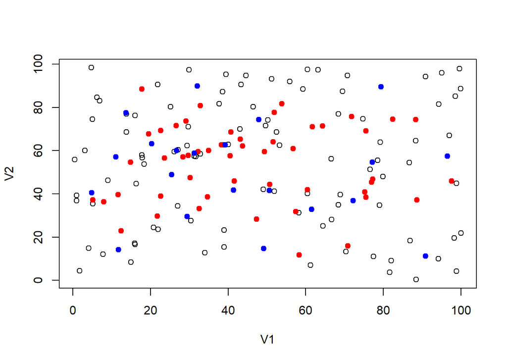

```r
plot(a)
points(random1_matrix[,3:4], col="red", pch=19)
points(facilitiesupdated[,2:3], col="blue", pch=19)
```

```r
as.numeric(tail(iterates[,2:3],1))
```

```
## [1] 1114953      21
```

### Question 4, Average and Best Results for 1000 Trials

Since we want to run query for 1000 times, the code is updated with while loop and added below. Also, trials matrix is created that shows optimal values in first column and number of facilities in second column.

```r
trials2 = matrix(rep(0,2000), nrow=1000,ncol=2)
number.of.trials2 = 1
while (number.of.trials2 < 1001){

  random_matrix  = matrix(rep(0,200), nrow=50,ncol=2)
  allocation_matrix = matrix(rep(0,5000), nrow=50,ncol=100)
  order = matrix(sample(c(1:100)),nrow = 50, ncol = 2)
  for(i in 1:50){
    for(j in 1:2){
      random_matrix[i,j] = order[i,j]
      allocation_matrix[i,random_matrix[i,j]] = 1
    }
  }

  random_matrix <- cbind(random_matrix, matrix(rep(0,150),nrow=50,ncol=3))

  k=1
  while(k<25){
    for(j in 1:50){
      tempa = a[random_matrix[j,1:2],]
      nominator1 = 0
      nominator2 = 0
      denominator = 0

      for(i in 1:2){
        nominator1 = nominator1 + (totalcost[j,random_matrix[j,i]] * tempa[[i,1]]) / (euclidean(random_matrix[j,2:3],a[random_matrix[j,i],]))
      }

      for(i in 1:2){
        nominator2 = nominator2 + (totalcost[j,random_matrix[j,i]] * tempa[[i,2]]) / (euclidean(random_matrix[j,2:3],a[random_matrix[j,i],]))
      }

      for(i in 1:2){
        denominator = denominator + (totalcost[j,random_matrix[j,i]]) / (euclidean(random_matrix[j,2:3],a[random_matrix[j,i],]))
      }

      x1 = nominator1/denominator
      x2 = nominator2/denominator
      facility <- t(matrix(c(x1,x2)))
      distance_matrix = NULL

      for(i in 1:2){
        distance_matrix = cbind(distance_matrix, euclidean(facility, (a[random_matrix[j,i],])))
      }
      objectivevalue = c(totalcost[j,random_matrix[j,1]],totalcost[j, random_matrix[j,2]]) %*% t(distance_matrix[])

      random_matrix[j,3] = x1
      random_matrix[j,4] = x2
      random_matrix[j,5] = objectivevalue
      k = k+1
    }
  }
  iterates = t(matrix(c(0,sum(random_matrix[,5]),50)))
  nearestmatrix = matrix(rep(0,200),nrow=100,ncol=2)
  for(j in 1:100){
    mindist = 9999999999999999999999
    for(i in 1:50){
      if(euclidean(a[j,],random_matrix[i,3:4]) < mindist){
        mindist = euclidean(a[j,],random_matrix[i,3:4])
        nearestf = i
      }
    }
    nearestmatrix[j,] = c(j,nearestf)
  }
  totalobjectivefirst = 0
  facilitiesupdated = NULL
  for(i in 1:50){
    tempset = NULL
    for(j in 1:100){
      if(nearestmatrix[j,2] == i){
        tempset = cbind(tempset,j)
      }
    }

    if(is.null(tempset) == TRUE) next

    locationmatrix <- cbind(i,tempset)
    nominator1 = 0
    nominator2 = 0
    denominator = 0

    for(k in 2:length(locationmatrix)){
      nominator1 = nominator1 + totalcost[i,locationmatrix[k]] * a[[locationmatrix[k],1]] / (euclidean(random_matrix[i,2:3],a[locationmatrix[k],]))
    }

    for(k in 2:length(locationmatrix)){
      nominator2 = nominator2 + totalcost[i,locationmatrix[k]] * a[[locationmatrix[k],2]] / (euclidean(random_matrix[i,2:3],a[locationmatrix[k],]))
    }

    for(k in 2:length(locationmatrix)){
      denominator = denominator + totalcost[i,locationmatrix[k]] / (euclidean(random_matrix[i,2:3],a[locationmatrix[k],]))
    }

    x1 = nominator1/denominator
    x2 = nominator2/denominator
    facilitiesupdated = rbind(facilitiesupdated, c(i, x1, x2))
    facility <- t(matrix(c(x1,x2)))
    distance_matrix = NULL
    for (k in 1 : length(tempset)) {
      distance_matrix = cbind(distance_matrix, euclidean(facility, (a[tempset[1,k],])))
    }

    currenttotal = NULL
    for(k in 1 : length(tempset)){
      currenttotal = cbind(currenttotal, totalcost[i,tempset[1,k]])
    }
    totalobjectivefirst = totalobjectivefirst + currenttotal[] %*% t(distance_matrix[])
  }
  totalobjective = totalobjectivefirst
  n=1
  iterates <- rbind(iterates, t(matrix(c(n,totalobjectivefirst,nrow(facilitiesupdated)))))


  while(abs(totalobjective - temp) > 0.001){
    temp = totalobjective
    nearestmatrix = matrix(rep(0,200),nrow=100,ncol=2)
    for(j in 1:100){
      mindist = 9999999999999999999999
      nearestf = 0
      for(i in 1:length(facilitiesupdated[,1])){
        if(euclidean(a[j,],random_matrix[i,3:4]) < mindist){
          mindist = euclidean(a[j,],random_matrix[i,3:4])
          nearestf = i
        }
      }
      nearestmatrix[j,] = c(j,nearestf)
    }
    aliasfacup = facilitiesupdated
    facilitiesupdated = NULL
    locationmatrix = NULL
    totalobjective = 0

    for(i in 1:50){

      tempset = NULL
      for(j in 1:100){
        if(nearestmatrix[j,2] == i){
          tempset = cbind(tempset,j)
        }
      }

      if(is.null(tempset) == TRUE) next

      locationmatrix <- cbind(i,tempset)
      nominator1 = 0
      nominator2 = 0
      denominator = 0

      for(k in 2:length(locationmatrix)){
        nominator1 = nominator1 + totalcost[i,locationmatrix[k]] * a[[locationmatrix[k],1]] / ((euclidean(aliasfacup[i,2:3],a[locationmatrix[k],])) + 0.01)
      }

      for(k in 2:length(locationmatrix)){
        nominator2 = nominator2 + totalcost[i,locationmatrix[k]] * a[[locationmatrix[k],2]] / ((euclidean(aliasfacup[i,2:3],a[locationmatrix[k],])) + 0.01)
      }

      for(k in 2:length(locationmatrix)){
        denominator = denominator + totalcost[i,locationmatrix[k]] / ((euclidean(aliasfacup[i,2:3],a[locationmatrix[k],])) + 0.01)
      }

      aliasfacup = NULL
      x1 = nominator1/denominator
      x2 = nominator2/denominator
      facilitiesupdated = rbind(facilitiesupdated, c(i, x1, x2))
      facility <- t(matrix(c(x1,x2)))
      distance_matrix = NULL
      for (k in 1 : length(tempset)) {
        distance_matrix = cbind(distance_matrix, euclidean(facility, (a[tempset[1,k],])))
      }

      currenttotal = NULL
      for(k in 1 : length(tempset)){
        currenttotal = cbind(currenttotal, totalcost[i,tempset[1,k]])
      }
      totalobjective = totalobjective + currenttotal[] %*% t(distance_matrix[])

    }
    n=n+1
    iterates <- rbind(iterates, t(matrix(c(n,totalobjective,nrow(facilitiesupdated)))))
  }
  trials2[number.of.trials2,1] = totalobjective
  trials2[number.of.trials2,2] = nrow(facilitiesupdated)
  number.of.trials2 = number.of.trials2 + 1
}
average.optimalvalue = mean(trials2[,1])
average.number.of.facilities = mean(trials2[,2])
minimum.optimalvalue = min(trials2[,1])
minimum.number.of.facilities = min(trials2[,2])
```

```r
head(trials2)
```

```
##         [,1] [,2]
## [1,] 1232372   18
## [2,] 1420899   22
## [3,] 1178038   18
## [4,] 1119778   20
## [5,] 1633544   10
## [6,] 1372030   17
```

So, the average and minimum values are below.

```r
average.optimalvalue
```

```
## [1] 1448947
```

```r
average.number.of.facilities
```

```
## [1] 16.81
```

```r
minimum.optimalvalue
```

```
## [1] 630259.5
```

```r
minimum.number.of.facilities
```

```
## [1] 4
```